# Análisis descriptivo

2026-03-29

Cargamos las librerías que vamos a utilizar

```r
library(ggplot2)
library(corrplot)
library(readr)
```

```r
datos_prod <- read_csv("base_productividad.csv")
datos_ebe <- read_csv("base_ebe.csv")
datos_imp <- read_csv("base_imp.csv")
```

No comprobamos base_smi porque esas variables se incluyen en base_imp

```r
str(datos_prod)
```

```
## spc_tbl_ [64 × 6] (S3: spec_tbl_df/tbl_df/tbl/data.frame)
##  $ fecha  : chr [1:64] "2008T1" "2008T2" "2008T3" "2008T4" ...
##  $ tiempo : num [1:64] 2008 2008 2008 2009 2009 ...
##  $ pib    : num [1:64] 4.535 4.522 3.428 0.385 -3.604 ...
##  $ prod   : num [1:64] 0.282 0.905 1.167 1.309 1.845 ...
##  $ paro   : num [1:64] 9.6 10.4 11.2 13.8 17.2 ...
##  $ salario: num [1:64] 2342 2451 2350 2584 2441 ...
##  - attr(*, "spec")=
##   .. cols(
##   ..   fecha = col_character(),
##   ..   tiempo = col_double(),
##   ..   pib = col_double(),
##   ..   prod = col_double(),
##   ..   paro = col_double(),
##   ..   salario = col_double()
##   .. )
##  - attr(*, "problems")=<externalptr>
```

```r
str(datos_ebe)
```

```
## spc_tbl_ [64 × 6] (S3: spec_tbl_df/tbl_df/tbl/data.frame)
##  $ fecha  : chr [1:64] "2008T1" "2008T2" "2008T3" "2008T4" ...
##  $ tiempo : num [1:64] 2008 2008 2008 2009 2009 ...
##  $ pib    : num [1:64] 4.535 4.522 3.428 0.385 -3.604 ...
##  $ ebe    : num [1:64] -0.551 2.107 -1.294 0.243 -3.135 ...
##  $ paro   : num [1:64] 9.6 10.4 11.2 13.8 17.2 ...
##  $ salario: num [1:64] 2342 2451 2350 2584 2441 ...
##  - attr(*, "spec")=
##   .. cols(
##   ..   fecha = col_character(),
##   ..   tiempo = col_double(),
##   ..   pib = col_double(),
##   ..   ebe = col_double(),
##   ..   paro = col_double(),
##   ..   salario = col_double()
##   .. )
##  - attr(*, "problems")=<externalptr>
```

```r
str(datos_imp)
```

```
## spc_tbl_ [64 × 8] (S3: spec_tbl_df/tbl_df/tbl/data.frame)
##  $ fecha        : chr [1:64] "2008T1" "2008T2" "2008T3" "2008T4" ...
##  $ tiempo       : num [1:64] 2008 2008 2008 2009 2009 ...
##  $ pib          : num [1:64] 4.535 4.522 3.428 0.385 -3.604 ...
##  $ ebe          : num [1:64] -0.551 2.107 -1.294 0.243 -3.135 ...
##  $ paro         : num [1:64] 9.6 10.4 11.2 13.8 17.2 ...
##  $ salario      : num [1:64] 2342 2451 2350 2584 2441 ...
##  $ smi          : num [1:64] 600 600 600 600 624 ...
##  $ impuestos_sub: num [1:64] -5.154 -9.475 -3.521 -0.715 -5.168 ...
##  - attr(*, "spec")=
##   .. cols(
##   ..   fecha = col_character(),
##   ..   tiempo = col_double(),
##   ..   pib = col_double(),
##   ..   ebe = col_double(),
##   ..   paro = col_double(),
##   ..   salario = col_double(),
##   ..   smi = col_double(),
##   ..   impuestos_sub = col_double()
##   .. )
##  - attr(*, "problems")=<externalptr>
```

```r
summary(datos_prod)
```

```
##     fecha               tiempo          pib                prod
##  Length:64          Min.   :2008   Min.   :-20.8828   Min.   :-5.32220
##  Class :character   1st Qu.:2012   1st Qu.: -0.9405   1st Qu.:-0.01268
##  Mode  :character   Median :2016   Median :  3.0379   Median : 0.65980
##                     Mean   :2016   Mean   :  2.1064   Mean   : 0.53842
##                     3rd Qu.:2020   3rd Qu.:  4.4242   3rd Qu.: 1.97330
##                     Max.   :2024   Max.   : 21.3945   Max.   : 4.31170
##       paro          salario
##  Min.   : 9.60   Min.   :2342
##  1st Qu.:14.31   1st Qu.:2479
##  Median :17.50   Median :2584
##  Mean   :18.10   Mean   :2602
##  3rd Qu.:21.20   3rd Qu.:2666
##  Max.   :26.94   Max.   :3146
```

```r
summary(datos_ebe)
```

```
##     fecha               tiempo          pib                ebe
##  Length:64          Min.   :2008   Min.   :-20.8828   Min.   :-18.2925
##  Class :character   1st Qu.:2012   1st Qu.: -0.9405   1st Qu.: -0.5563
##  Mode  :character   Median :2016   Median :  3.0379   Median :  0.2737
##                     Mean   :2016   Mean   :  2.1064   Mean   :  0.6057
##                     3rd Qu.:2020   3rd Qu.:  4.4242   3rd Qu.:  1.6165
##                     Max.   :2024   Max.   : 21.3945   Max.   : 15.6510
##       paro          salario
##  Min.   : 9.60   Min.   :2342
##  1st Qu.:14.31   1st Qu.:2479
##  Median :17.50   Median :2584
##  Mean   :18.10   Mean   :2602
##  3rd Qu.:21.20   3rd Qu.:2666
##  Max.   :26.94   Max.   :3146
```

```r
summary(datos_imp)
```

```
##     fecha               tiempo          pib                ebe
##  Length:64          Min.   :2008   Min.   :-20.8828   Min.   :-18.2925
##  Class :character   1st Qu.:2012   1st Qu.: -0.9405   1st Qu.: -0.5563
##  Mode  :character   Median :2016   Median :  3.0379   Median :  0.2737
##                     Mean   :2016   Mean   :  2.1064   Mean   :  0.6057
##                     3rd Qu.:2020   3rd Qu.:  4.4242   3rd Qu.:  1.6165
##                     Max.   :2024   Max.   : 21.3945   Max.   : 15.6510
##       paro          salario          smi         impuestos_sub
##  Min.   : 9.60   Min.   :2342   Min.   : 600.0   Min.   :-42.6413
##  1st Qu.:14.31   1st Qu.:2479   1st Qu.: 641.4   1st Qu.: -1.8915
##  Median :17.50   Median :2584   Median : 651.9   Median :  0.6157
##  Mean   :18.10   Mean   :2602   Mean   : 754.1   Mean   :  1.1276
##  3rd Qu.:21.20   3rd Qu.:2666   3rd Qu.: 912.5   3rd Qu.:  3.0669
##  Max.   :26.94   Max.   :3146   Max.   :1080.0   Max.   : 56.5620
```

```r
dim(datos_prod)
```

```
## [1] 64  6
```

```r
dim(datos_ebe)
```

```
## [1] 64  6
```

```r
dim(datos_imp)
```

```
## [1] 64  8
```

```r
which(is.na(datos_prod))
```

```
## integer(0)
```

No hay valores missing

```r
which(is.na(datos_ebe))
```

```
## integer(0)
```

No hay valores missing

```r
which(is.na(datos_imp))
```

```
## integer(0)
```

En ninguno de los casos tenemos valores missing, por lo que no es necesario realizar ningún tratamiento de este tipo.

# Estadísticos descriptivos

Realizamos el Análisis Estadístico Descriptivo Univariante

## Variable dependiente: salario

Analizamos el salario (es el mismo en todas las bases que vamos a utilizar)

```r
summary(datos_prod$salario)
```

```
##    Min. 1st Qu.  Median    Mean 3rd Qu.    Max.
##    2342    2479    2584    2602    2666    3146
```

```r
dd<-density(datos_prod$salario)
moda_dd<-dd$x[which(dd$y==max(dd$y))]
moda_dd
```

```
## [1] 2490.605
```

El salario medio es 2602 y el mediano de 2584. El salario modal es de 2490,605. El salario con valor mínimo es de 2342 y el máximo de 3146 euros.

Distribución de los salarios.

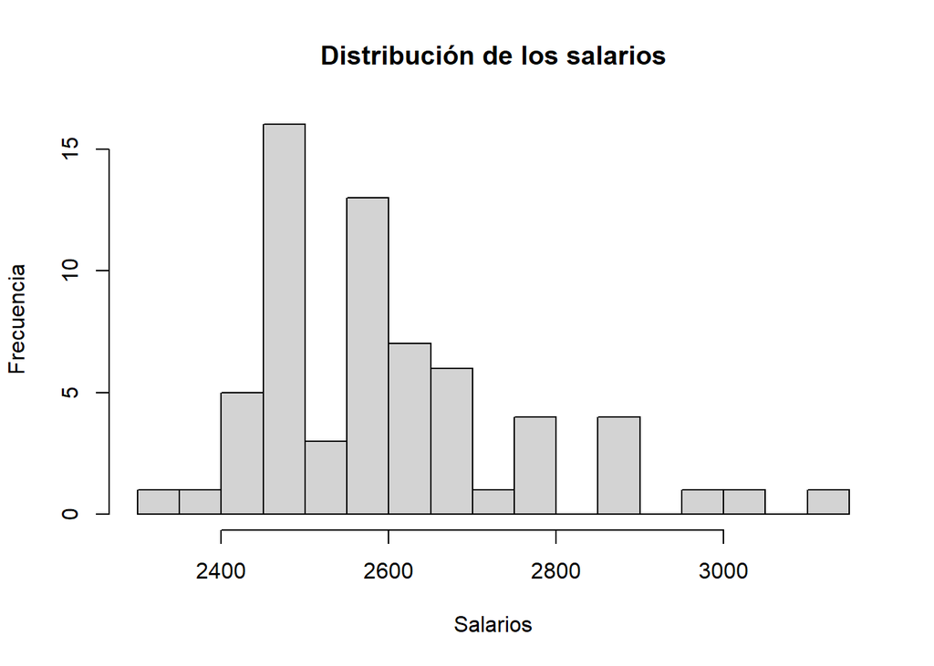

```r
hist(datos_prod$salario, breaks = 15,
     main = "Distribución de los salarios",
     xlab = "Salarios", ylab = "Frecuencia")
```

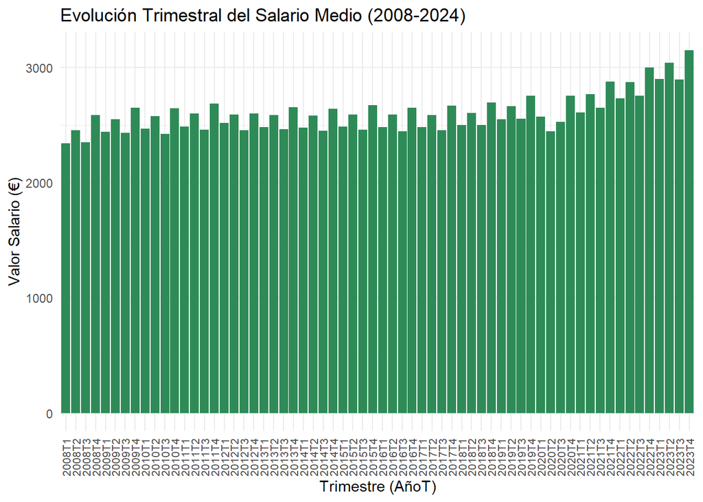

```r
ggplot(datos_prod, aes(x = factor(fecha), y = salario, fill = salario > 0)) +
  geom_col() +
  scale_fill_manual(values = c("seagreen"), guide = "none") +
  labs(
    title = "Evolución Trimestral del Salario Medio (2008-2024)",
    x = "Trimestre (AñoT)",
    y = "Valor Salario (€)"
  ) +
  theme_minimal() +
  theme(axis.text.x = element_text(angle = 90, vjust = 0.5, size = 8))
```

Como no se aprecia bien en que momento se alcanza el salario mínimo, lo comprobamos

```r
datos_prod[which(datos_prod$salario == min(datos_prod$salario)),]
```

```
## # A tibble: 1 × 6
##   fecha  tiempo   pib  prod  paro salario
##   <chr>   <dbl> <dbl> <dbl> <dbl>   <dbl>
## 1 2008T1   2008  4.54 0.282   9.6   2342.
```

## Variables explicativas

Llevamos a cabo un análisis descriptivo multivariante con estas variables

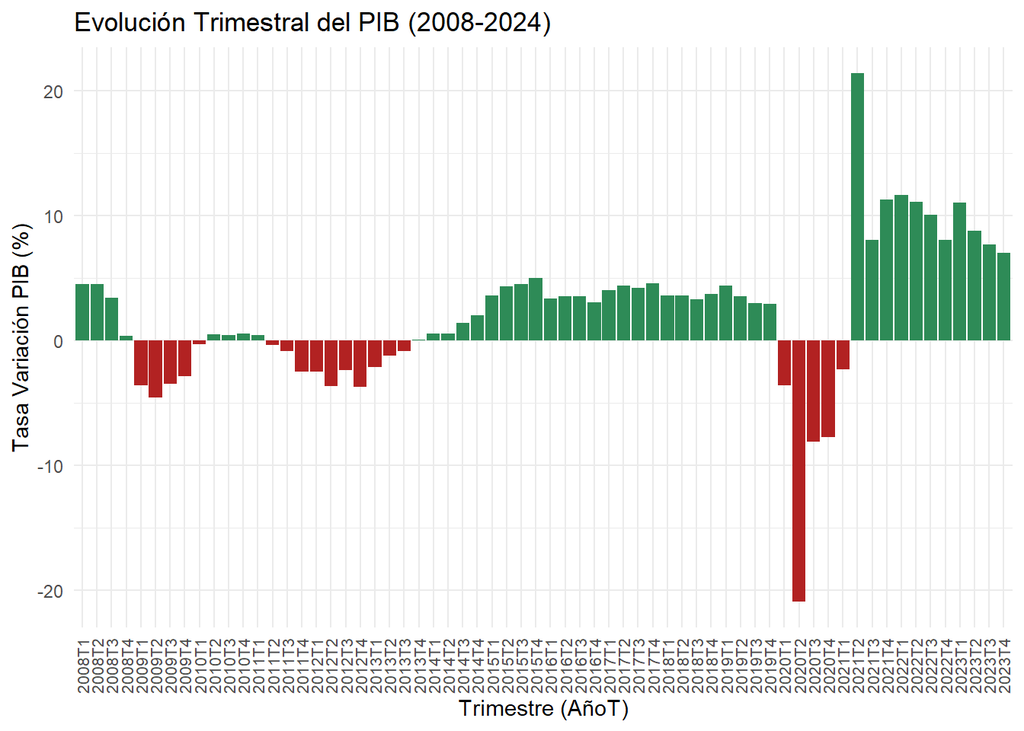

```r
ggplot(datos_prod, aes(x = factor(fecha), y = pib, fill = pib > 0)) +
  geom_col() +
  scale_fill_manual(values = c("firebrick", "seagreen"), guide = "none") +
  labs(
    title = "Evolución Trimestral del PIB (2008-2024)",
    x = "Trimestre (AñoT)",
    y = "Tasa Variación PIB (%)"
  ) +
  theme_minimal() +
  theme(axis.text.x = element_text(angle = 90, vjust = 0.5, size = 8))
```

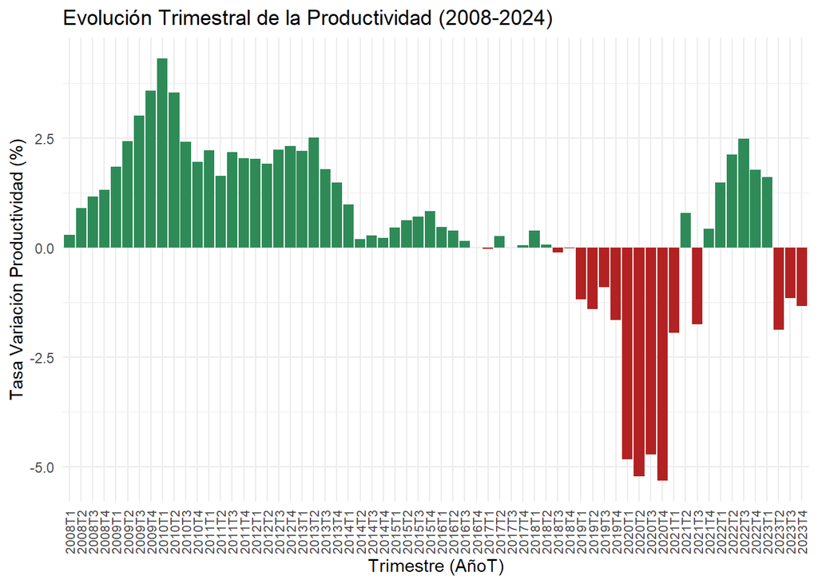

```r
ggplot(datos_prod, aes(x = factor(fecha), y = prod, fill = prod > 0)) +
  geom_col() +
  scale_fill_manual(values = c("firebrick", "seagreen"), guide = "none") +
  labs(
    title = "Evolución Trimestral de la Productividad (2008-2024)",
    x = "Trimestre (AñoT)",
    y = "Tasa Variación Productividad (%)"
  ) +
  theme_minimal() +
  theme(axis.text.x = element_text(angle = 90, vjust = 0.5, size = 8))
```

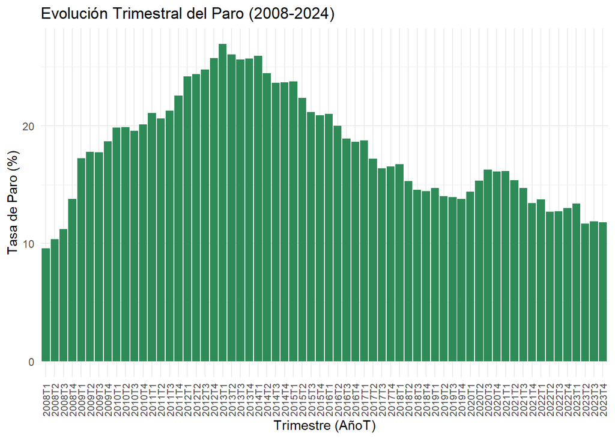

```r
ggplot(datos_prod, aes(x = factor(fecha), y = paro, fill = paro > 0)) +
  geom_col() +
  scale_fill_manual(values = c("seagreen"), guide = "none") +
  labs(
    title = "Evolución Trimestral del Paro (2008-2024)",
    x = "Trimestre (AñoT)",
    y = "Tasa de Paro (%)"
  ) +
  theme_minimal() +
  theme(axis.text.x = element_text(angle = 90, vjust = 0.5, size = 8))
```

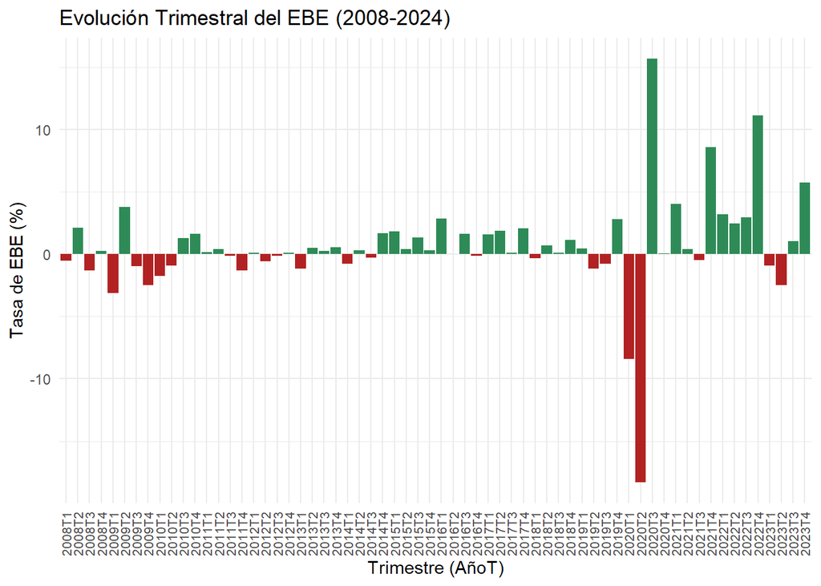

```r
ggplot(datos_ebe, aes(x = factor(fecha), y = ebe, fill = ebe > 0)) +
  geom_col() +
  scale_fill_manual(values = c("firebrick", "seagreen"), guide = "none") +
  labs(
    title = "Evolución Trimestral del EBE (2008-2024)",
    x = "Trimestre (AñoT)",
    y = "Tasa de EBE (%)"
  ) +
  theme_minimal() +
  theme(axis.text.x = element_text(angle = 90, vjust = 0.5, size = 8))
```

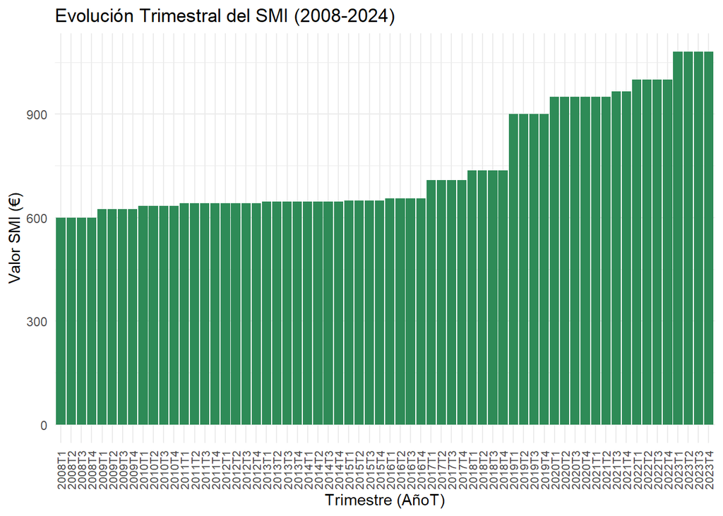

```r
ggplot(datos_imp, aes(x = factor(fecha), y = smi, fill = smi > 0)) +
  geom_col() +
  scale_fill_manual(values = c("seagreen"), guide = "none") +
  labs(
    title = "Evolución Trimestral del SMI (2008-2024)",
    x = "Trimestre (AñoT)",
    y = "Valor SMI (€)"
  ) +
  theme_minimal() +
  theme(axis.text.x = element_text(angle = 90, vjust = 0.5, size = 8))
```

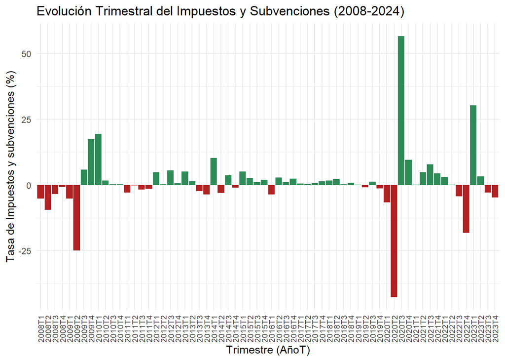

```r
ggplot(datos_imp, aes(x = factor(fecha), y = impuestos_sub, fill = impuestos_sub > 0)) +
  geom_col() +
  scale_fill_manual(values = c("firebrick", "seagreen"), guide = "none") +
  labs(
    title = "Evolución Trimestral del Impuestos y Subvenciones (2008-2024)",
    x = "Trimestre (AñoT)",
    y = "Tasa de Impuestos y subvenciones (%)"
  ) +
  theme_minimal() +
  theme(axis.text.x = element_text(angle = 90, vjust = 0.5, size = 8))
```

Variable temporal: desde 2008T1 a 2023T4

Tasa variación trimestral del PIB: - Mínimo -20.8828 en 2020T2 - Máximo 21.3945 en 2021T2

Tasa de Paro: - Mínimo 9.60 en 2008T1 - Máximo 26.94 en 2013T1

Salario medio: - Mínimo 2342 en 2008T1 - Máximo 3146 en 2023T4

EBE: - Mínimo -18.2925 en 2020T2 - Máximo 15.6510 en 2020T3

## Correlaciones

Para la base con productividad

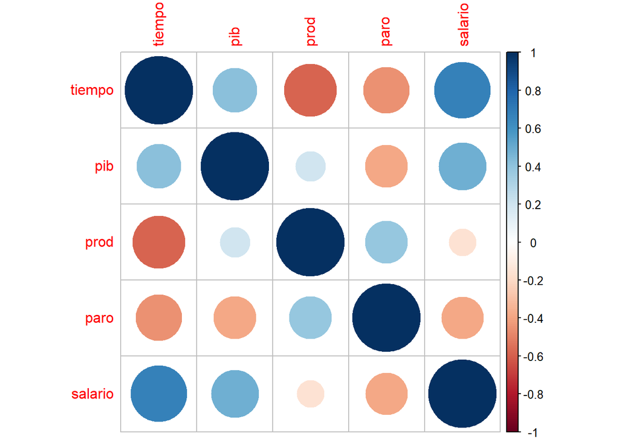

```r
mcor <- cor(datos_prod[, -1])
corrplot(mcor)
```

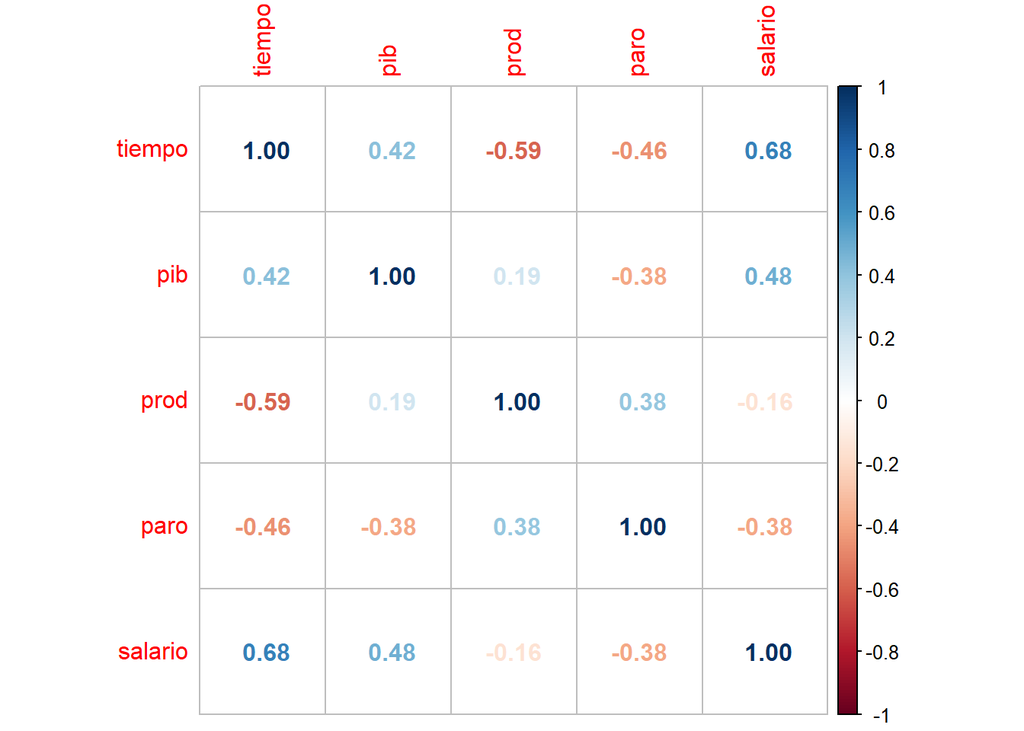

```r
corrplot(mcor,method = "number")
```

Para la base con EBE

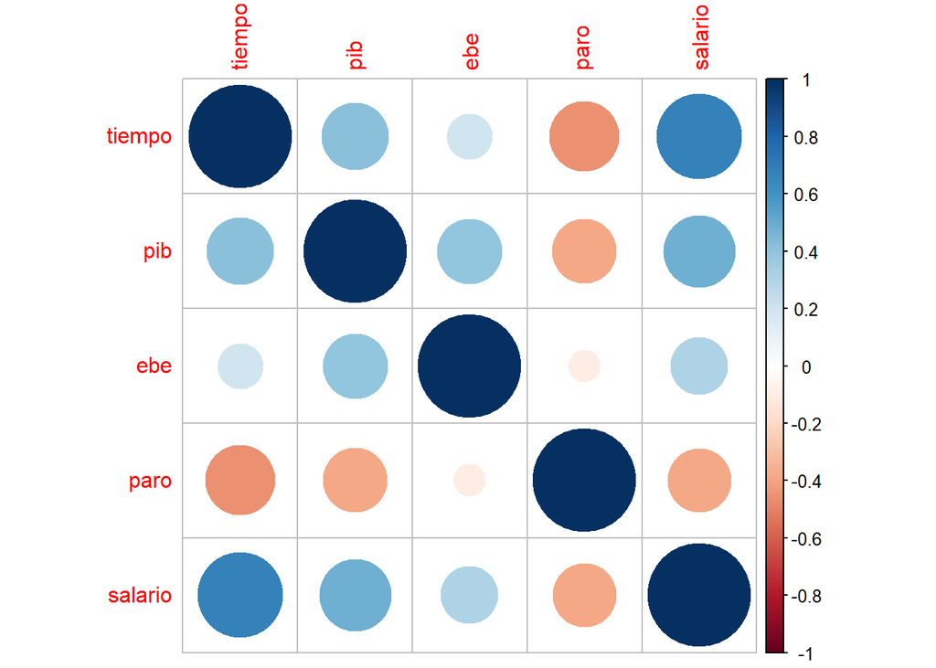

```r
mcor <- cor(datos_ebe[, -1])
corrplot(mcor)
```

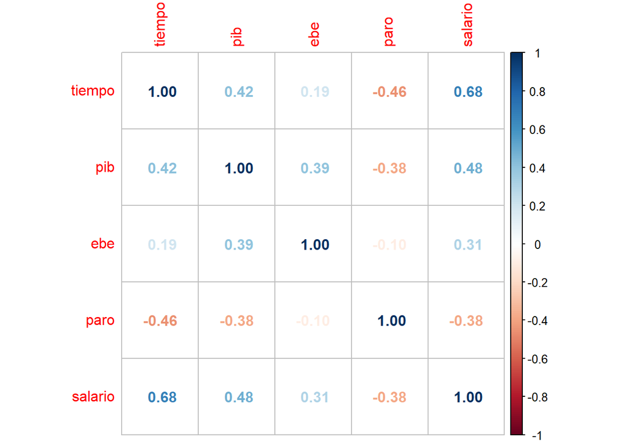

```r
corrplot(mcor,method = "number")
```

Para la base con smi e impuestos y subvenciones

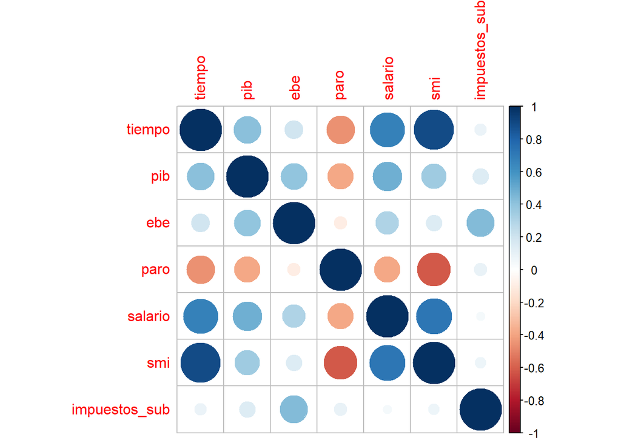

```r
mcor <- cor(datos_imp[, -1])
corrplot(mcor)
```

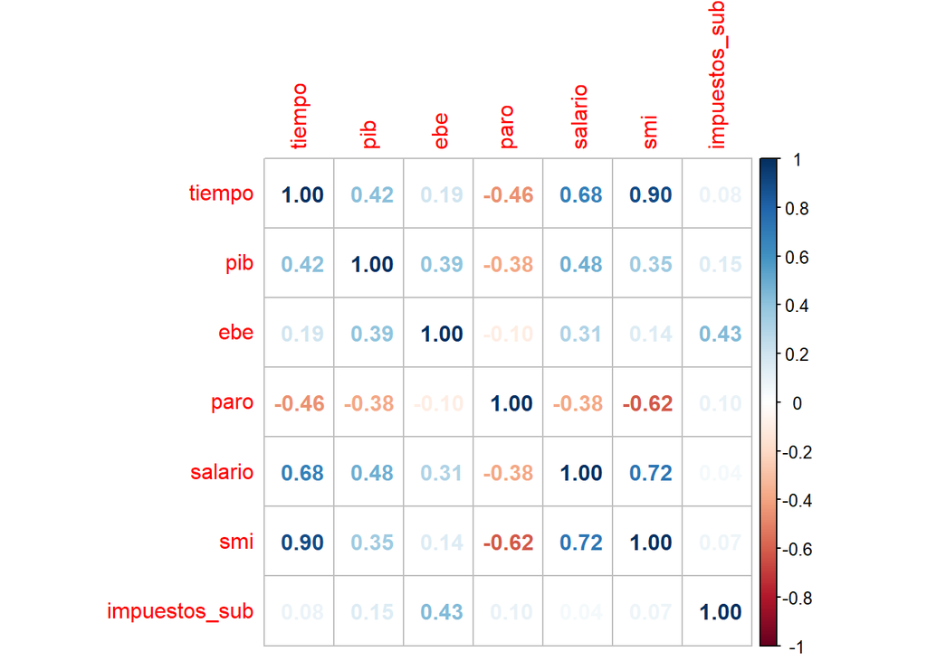

```r
corrplot(mcor,method = "number")
```

# Evolución temporal

Convertimos las columnas del dataframe en objetos ts

```r
salario_ts <- ts(datos_prod$salario, start = c(2008, 1), frequency = 4)
pib_ts     <- ts(datos_prod$pib,     start = c(2008, 1), frequency = 4)
paro_ts    <- ts(datos_prod$paro,    start = c(2008, 1), frequency = 4)
prod_ts    <- ts(datos_prod$prod,    start = c(2008, 1), frequency = 4)
ebe_ts    <- ts(datos_ebe$ebe,    start = c(2008, 1), frequency = 4)
smi_ts <- ts(datos_imp$smi, start = c(2008, 1), frequency = 4)
imp_sub_ts <- ts(datos_imp$impuestos_sub, start = c(2008, 1), frequency = 4)
```

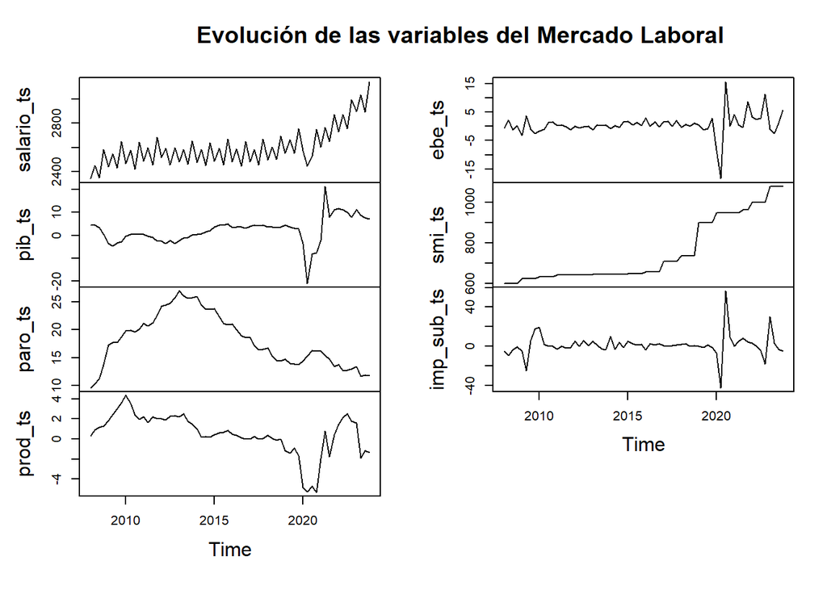

```r
plot.ts(cbind(salario_ts, pib_ts, paro_ts, prod_ts, ebe_ts, smi_ts, imp_sub_ts),
        main="Evolución de las variables del Mercado Laboral")
```

Dispersión

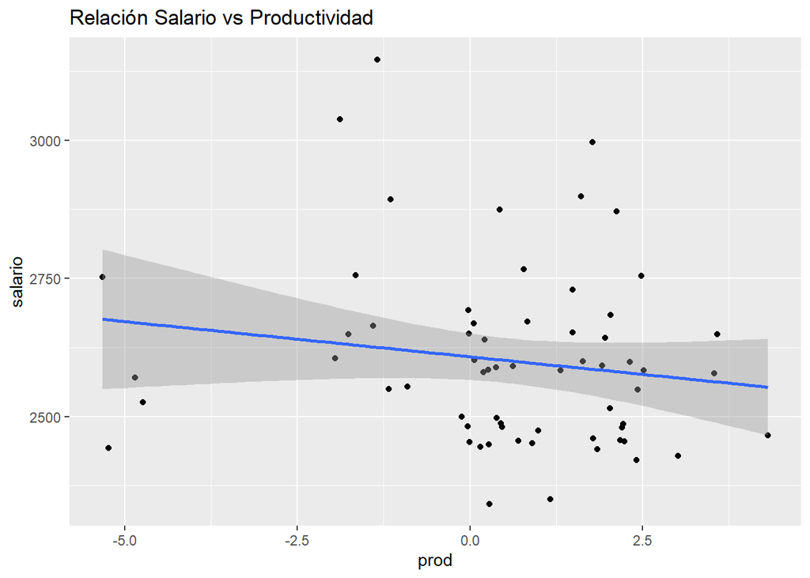

```r
ggplot(datos_prod, aes(x=prod, y=salario)) + geom_point() + geom_smooth(method="lm") +
  labs(title="Relación Salario vs Productividad")
```

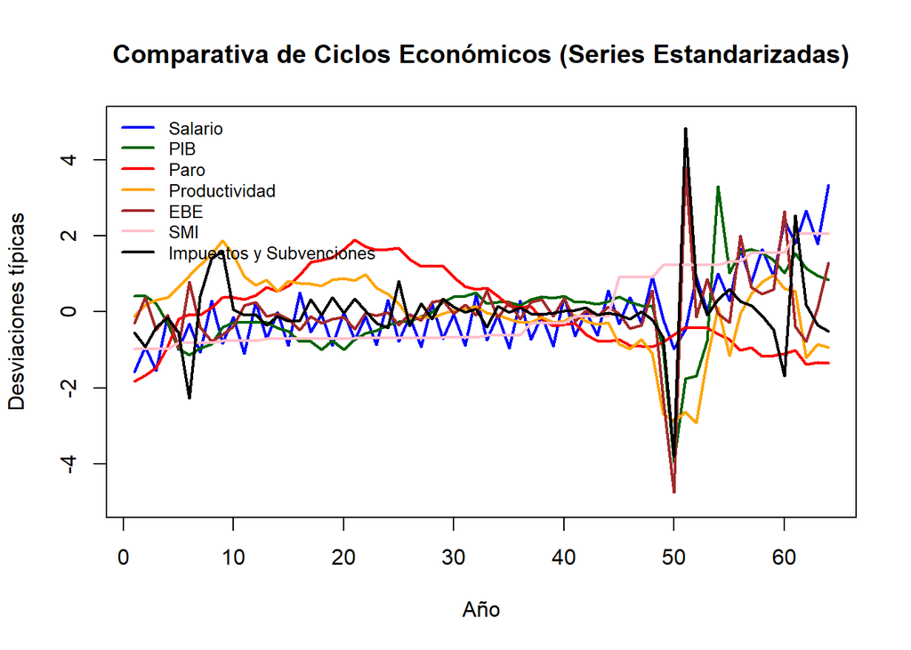

```r
# Estandarizamos para comparar movimientos relativos
plot(scale(salario_ts), type = "l", col = "blue", lwd = 2, ylim = c(-5, 5),
     main = "Comparativa de Ciclos Económicos (Series Estandarizadas)",
     ylab = "Desviaciones típicas", xlab = "Año")
lines(scale(pib_ts), col = "darkgreen", lwd = 2)
lines(scale(paro_ts), col = "red", lwd = 2)
lines(scale(prod_ts), col = "orange", lwd = 2)
lines(scale(ebe_ts), col = "brown", lwd = 2)
lines(scale(smi_ts), col = "pink", lwd = 2)
lines(scale(imp_sub_ts), col = "black", lwd = 2)

# Añadimos una leyenda para que se entienda el gráfico
legend("topleft",
       legend = c("Salario", "PIB", "Paro", "Productividad", "EBE", "SMI", "Impuestos y Subvenciones"),
       col = c("blue", "darkgreen", "red", "orange", "brown", "pink", "black"),
       lty = 1, lwd = 2, bty = "n", cex = 0.8)
```